# The Team That Kicks More Wins More

Harry Williams

08/01/2021

# Introduction

Following Englands victory against Ireland in November 2020, Eddie Jones was quoted “The teams that kick the most win games”.[^1] Even as early as 2010, the then Wales kicking coach can be quoted saying the same thing.[^2] This analysis will examine those claims and see if there is any truth that teams that kick the most win the most.

## Data

### Competetions

| Competition | Type Of Team | Hemisphere |
| --- | --- | --- |
| Autumn Nations Cup | International | Northern |
| Currie Cup | Club | Southern |
| European Champions Cup | Club | Northern |
| Internationals | International | Mixed |
| Mitre 10 Cup | Club | Southern |
| Premiership | Club | Northern |
| Premiership Cup | Club | Northern |
| Pro 14 | Club | Northern |
| Rugby World Cup | International | Mixed |
| Six Nations | International | Northern |
| Super Rugby | Club | Southern |
| Super Rugby Aotearoa | Club | Southern |
| Super Rugby Australia | Club | Southern |
| Super Rugby Unlocked | Club | Southern |
| The Rugby Championship | International | Southern |

### Variables

The Variables collected from each match are as follows:

| Ball Carry | Line Break | Penalty Goal Successful | Scrum Won |
| --- | --- | --- | --- |
| Ball Carry Meters | Lineout Throw Won Clean | Penalty Missed | Tackle Made |
| Beat Defender | Lineout Won Own Throw | Points Scored | Tackle Missed |
| Conversion Missed | Lineout Won Steal | Possession | Total Turnovers Conceded |
| Conversion Successful | Mauls Won | Red Card | Total Turnovers Gained |
| Drop Goal Missed | Offload | Rucks Lost | Try Assist |
| Drop Kick Successful | Passes | Rucks Won | Try Scored |
| Kicks From Hand | Penalties Conceded | Scrum Lost | Yellow Card |

### Key Variables

Since we are looking at kicking the key variable we are looking at in the data is `Kicks From Hand`. This is the total number of kicks in play. This analysis will also look at `Win Rate`, the percentage number of wins for a team and `Kick Rate`, the percentage number of times a team kicked more than their opposition. Both have been calculated in the following ways:

$$Win\:Rate = \frac{Number\:of\:Matches\:Won}{Total\:Matches\:Played}$$

$$Kick\:Rate = \frac{Number\:of\:Times\:Kicked\: More\: Than\: Opposition}{Total\:Matches\:Played}$$

### Data Limitions

#### Rugby Pass Data

Although there is a total of 425 professional rugby matches, the majority of the matches are from 2020. For competitions currently being played e.g. The Rugby Premiership and Pro 14 only matches from current season are included in the dataset as this is the only data that can be collected from Rugby Pass. International matches are almost complete, however there are a few important matches from the World Cup (Semi-finals onwards) that are also missing.

| Year | Count |
| --- | --- |
| 2018 | 24 |
| 2019 | 82 |
| 2020 | 305 |
| 2021 | 14 |

#### Variable Limitions

The variables collected offer an overview of the matches. Unfortunately it is difficult to distinguish different circumstances. This is problematic when looking at kicking data. Tactically, a kick from a teams own 22 is very different from a kick from the halfway line or inside the oppositions half. This also applied to penalties as it is difficult to determine how each penalty was conceded. For example from the breakdown or scrum. These statistics would offer a much more detailed analysis than a general overview.

# Analysis

## Teams that kicks more than the opposition

### Percentage Number of Match Wins

Using the data, the percentage number of wins for teams that kick more than their opposition are as follows:

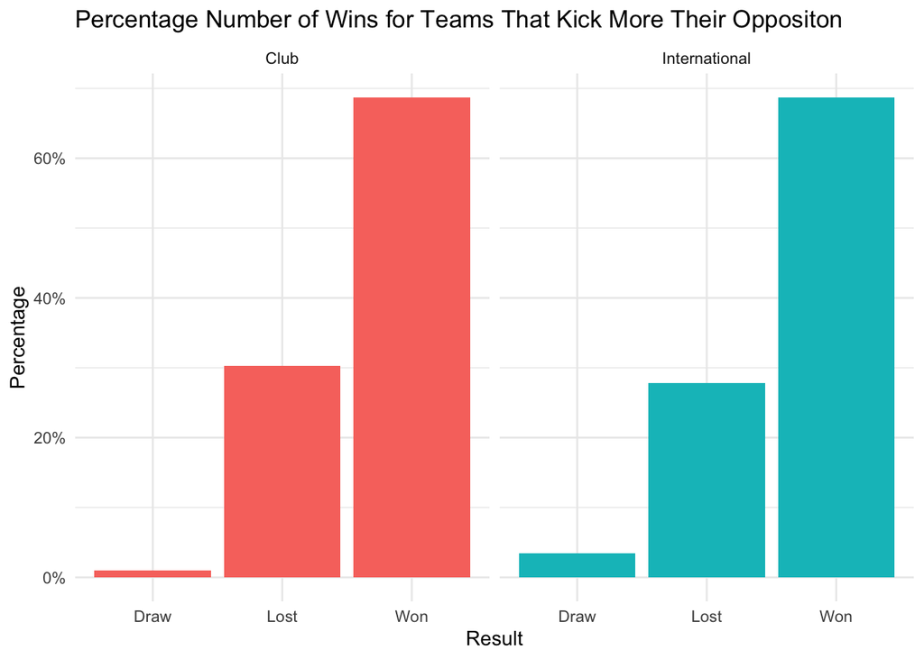

### Hypothesis Test

**Hypothesis Test**

Using this data lets put that to the test if the claim is statistically significant. If kicking did not have an impact on matches you would expect the proportion of match wins to be around 50%

H<sub>o</sub>: π matches won = 0.5

H<sub>A</sub>: π matches won > 0.5

α = 0.05

```r
tset_matches_sample <- test_matches

null_distribution <- tset_matches_sample %>%
  specify(response = won, success = "TRUE") %>%
  hypothesize(null = "point", p = 0.5) %>%
  generate(reps = 10000, type = "simulate") %>%
  calculate(stat = "prop")

observed_stat <- tset_matches_sample %>%
  specify(response = won, success = "TRUE") %>%
  calculate(stat = "prop")
```

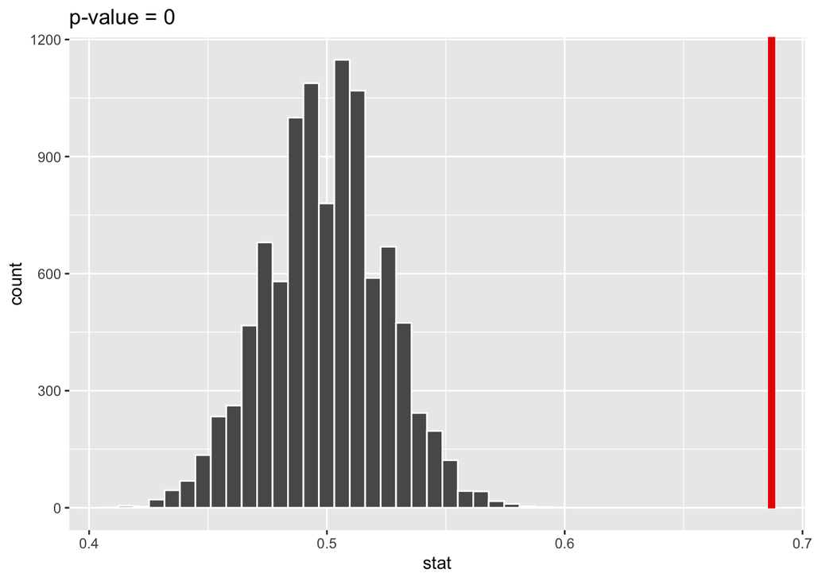

```r
  p_value <- null_distribution %>%
  get_p_value(obs_stat = observed_stat, direction = "both")


null_distribution %>%
  visualise(bins = 30) +
  shade_p_value(obs_stat = observed_stat, direction = "right") +
  labs(title = paste("p-value =", p_value ))
```

The p-value is less than α so we reject H<sub>0</sub> in favour of H<sub>A</sub>. There is enough evidence from our data to suggest that the proportion of wins is statistically significantly greater than the null value. This means that statistically, teams that kick more than their opposition win more games.

### Results of the test

The hypothesis test has shown that there is enough evidence from this dataset to say that teams that kick more than their opposition will win more of their games. A further computation can be carried out to give a percentage range within a 95% confidence interval.

### Estimated Percentage Wins

| Lower Confidence Interval | Upper Confidence Interval |
| --- | --- |
| 64.06% | 73.11% |

From this dataset we can estimate that teams that kick more than their opposition win between 64% - 73% of their total matches with a 95% confidence interval. It is clear that teams that kick more do win more of their matches. Kicking more does not result in winning games but these estimates do suggest that its does play a role.

## Win Rate vs Kick Rate

To try and explore the role kicking plays, we will look at the breakdown of the teams. Firstly looking at Win Rate vs Kick Rate

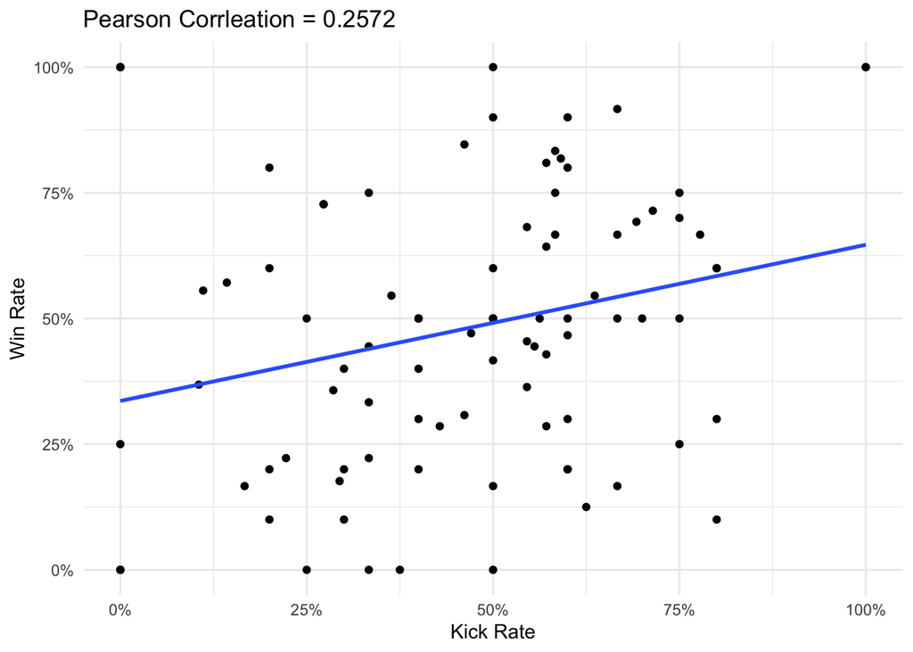

If we plot the two variables together there is a weak correlation of 0.257. There is quite a lot of spread within the data but there is still a general trend; teams that have a higher kick rate also have a higher win rate. As there is a weak correlation, there are other variables that also lead to a higher Win Rate, not just Kick Rate.

## Win Rate vs Average Number of Kicks Per Game

Firstly lets look at the top 10 teams by average number of kicks.

### Top 10 teams by Avgerage Number Of Kicks Per Game

| Rank | Team | Avg. No. Kicks Per Game | Draw | Lost | Won | Win Rate |
| --- | --- | --- | --- | --- | --- | --- |
| 1 | Western Force | 37.12 | 0 | 8 | 0 | 0% |
| 2 | England | 30.62 | 1 | 3 | 17 | 80.95% |
| 3 | France | 28.62 | 0 | 8 | 8 | 50% |
| 4 | Harlequins | 28.38 | 0 | 4 | 4 | 50% |
| 5 | Scarlets | 26.90 | 0 | 4 | 6 | 60% |
| 6 | South Africa | 26.31 | 1 | 3 | 9 | 69.23% |
| 7 | Wales | 26.18 | 0 | 4 | 18 | 81.82% |
| 8 | Ospreys | 25.89 | 0 | 5 | 4 | 44.44% |
| 9 | Cardiff Blues | 24.90 | 0 | 6 | 4 | 40% |
| 10 | Gwent Dragons | 24.90 | 0 | 7 | 3 | 30% |

Looking at the top 10 teams, there is no pattern between the teams with the higher average number of kicks and win rate. Interestingly of the top 10, 4 of the teams are international teams showing how kicking is more prevalent in the international game. If we drill down further we can see that this is the case for all matches:

| Type Of Team | Avg. No. Kicks Per Games |
| --- | --- |
| Club | 20.85 |
| International | 23.36 |

### Win Rate vs Average Number of Kicks Per Game Plot

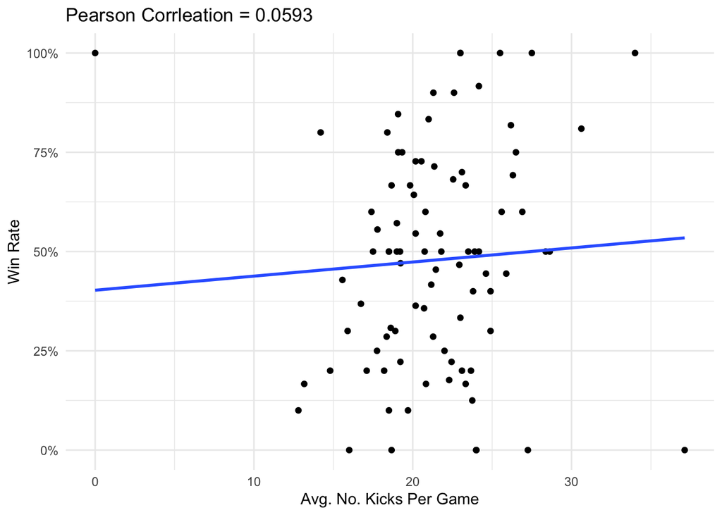

If we the look at the correlation we can see that there is even less of a correlation between the average number of kicks per game and win rate. This adds a level of complexity to the issue. We have seen that kicking more than the opposition can result is a higher win rate, however from this, simply having a high number of kicks per game does not. Further exploration is needed to try to explain this.

## Further Exploration

As the data is more complete when looking at international matches, this exploration will focus only on the international game. As we have seen teams that if a team kicks more than their opposition there is a higher chance of winning. Teams that do this more regularly also have a higher win rate. However having a higher number of kicks does not result in a better win rate. There are obviously more varaibles that can explain this.

### Correlation with `Kicks From Hand`

Below is a graph showing which other variables correlate with `Kicks From Hand`:

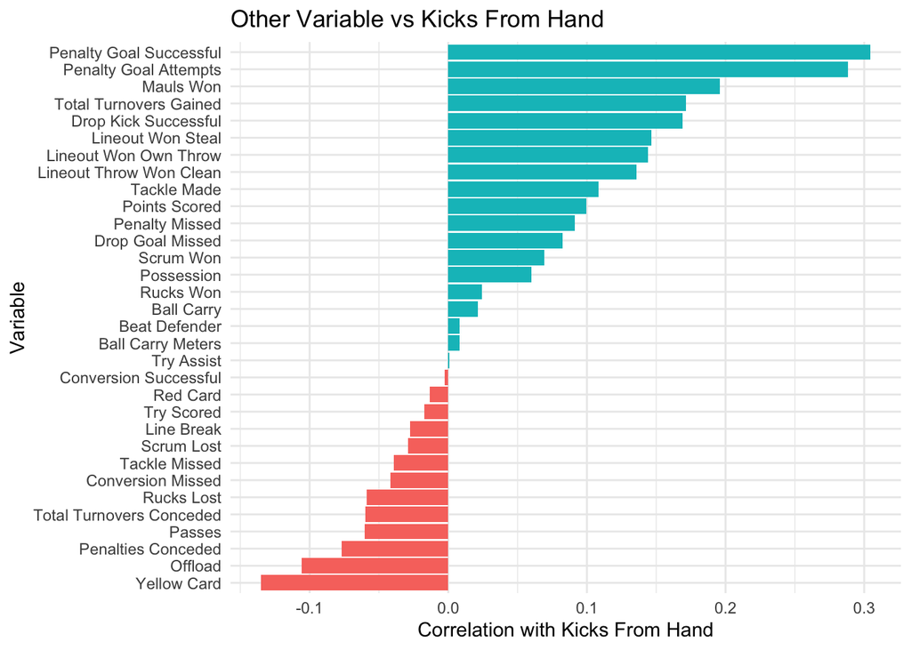

Anything over 0.2 shows a weak correlation. From this there appears to be a weak correlation between the Number of Kicks from hand and the number of Penalty Goals. This could perhaps explain why teams that kick more than their opposition have a higher chance of winning as the data suggests they are more likely to have more opportunities to kick at goal. However, further exploration is still needed to try to explain this correlation.

Unfortunately the data there is too much spread in the data and variables are not ideal to produce a predictive model but they can offer some insight by producing a explanatory model

### Explanatory Model

**Model Construction**

Penalty Goal Successful and team both look like good options

```r
mod1a <- lm(kicks_from_hand ~ team, data = model_data)
```

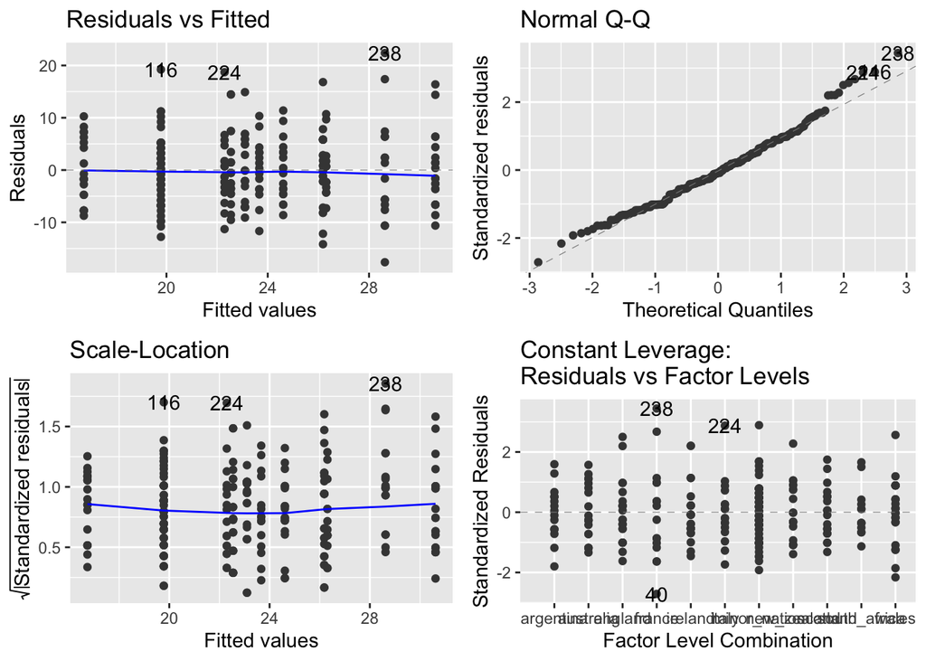

```r
autoplot(mod1a)
```

```r
summary(mod1a)
```

```
##
## Call:
## lm(formula = kicks_from_hand ~ team, data = model_data)
##
## Residuals:
##      Min       1Q   Median       3Q      Max
## -17.6250  -4.4860  -0.5455   4.2182  22.3750
##
## Coefficients:
##                  Estimate Std. Error t value Pr(>|t|)
## (Intercept)        16.737      1.539  10.873  < 2e-16 ***
## teamnew_zealand     6.363      2.150   2.960 0.003401 **
## teamengland        13.882      2.125   6.534 4.16e-10 ***
## teamsouth_africa    9.571      2.415   3.963 9.92e-05 ***
## teamireland         5.809      2.101   2.764 0.006177 **
## teamitaly           5.557      2.240   2.481 0.013834 *
## teamminor_nation    3.045      1.786   1.705 0.089500 .
## teamscotland        7.874      2.207   3.568 0.000439 ***
## teamwales           9.445      2.101   4.494 1.11e-05 ***
## teamfrance         11.888      2.277   5.222 4.01e-07 ***
## teamargentina       6.930      2.318   2.990 0.003096 **
## ---
## Signif. codes:  0 '***' 0.001 '**' 0.01 '*' 0.05 '.' 0.1 ' ' 1
##
## Residual standard error: 6.71 on 227 degrees of freedom
## Multiple R-squared:  0.2519, Adjusted R-squared:  0.2189
## F-statistic: 7.642 on 10 and 227 DF,  p-value: 1.679e-10
```

As with the top 10 teams with the highest average kicks per game, England, France, South Africa, Wales contribute towards kicking more in matches

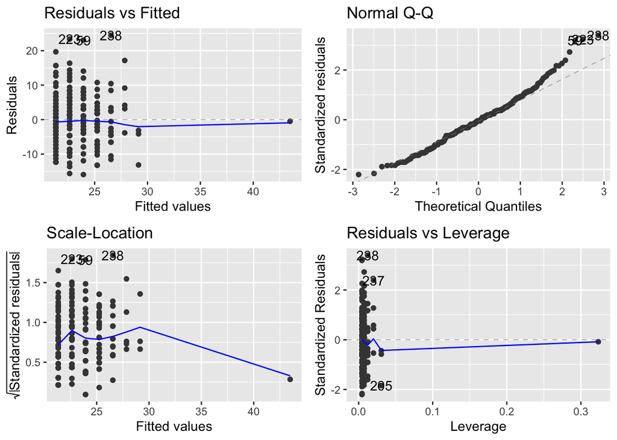

```r
mod1b <- lm(kicks_from_hand ~ penalty_goal_successful, data = model_data)

autoplot(mod1b)
```

```r
summary(mod1b)
```

```
##
## Call:
## lm(formula = kicks_from_hand ~ penalty_goal_successful, data = model_data)
##
## Residuals:
##      Min       1Q   Median       3Q      Max
## -15.9362  -4.5423  -0.3302   3.6698  24.4577
##
## Coefficients:
##                         Estimate Std. Error t value Pr(>|t|)
## (Intercept)              21.3302     0.6257  34.088  < 2e-16 ***
## penalty_goal_successful   1.3030     0.2652   4.913 1.67e-06 ***
## ---
## Signif. codes:  0 '***' 0.001 '**' 0.01 '*' 0.05 '.' 0.1 ' ' 1
##
## Residual standard error: 7.247 on 236 degrees of freedom
## Multiple R-squared:  0.0928, Adjusted R-squared:  0.08896
## F-statistic: 24.14 on 1 and 236 DF,  p-value: 1.674e-06
```

mod1a has the highest r^2 so that will be used.

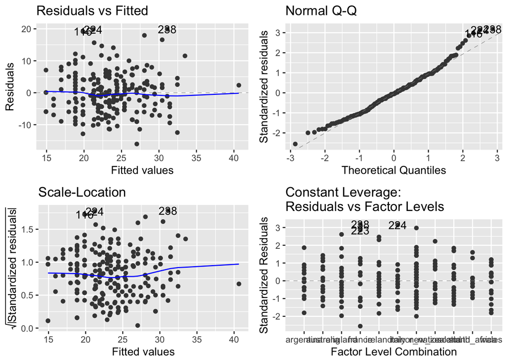

```r
mod2a <- lm(kicks_from_hand ~ team + penalty_goal_successful, data = model_data)

autoplot(mod2a)
```

```r
summary(mod2a)
```

```
##
## Call:
## lm(formula = kicks_from_hand ~ team + penalty_goal_successful,
##     data = model_data)
##
## Residuals:
##      Min       1Q   Median       3Q      Max
## -16.0407  -4.4340  -0.3357   3.9404  19.9036
##
## Coefficients:
##                         Estimate Std. Error t value Pr(>|t|)
## (Intercept)              14.9225     1.5584   9.575  < 2e-16 ***
## teamnew_zealand           6.9608     2.0873   3.335 0.000997 ***
## teamengland              13.4756     2.0602   6.541 4.03e-10 ***
## teamsouth_africa          9.0454     2.3428   3.861 0.000147 ***
## teamireland               6.4247     2.0411   3.148 0.001868 **
## teamitaly                 6.2981     2.1775   2.892 0.004197 **
## teamminor_nation          3.9192     1.7431   2.248 0.025518 *
## teamscotland              8.4494     2.1424   3.944 0.000107 ***
## teamwales                 8.4941     2.0492   4.145 4.80e-05 ***
## teamfrance               12.1183     2.2058   5.494 1.06e-07 ***
## teamargentina             6.3784     2.2489   2.836 0.004979 **
## penalty_goal_successful   1.0139     0.2535   3.999 8.61e-05 ***
## ---
## Signif. codes:  0 '***' 0.001 '**' 0.01 '*' 0.05 '.' 0.1 ' ' 1
##
## Residual standard error: 6.499 on 226 degrees of freedom
## Multiple R-squared:  0.3013, Adjusted R-squared:  0.2673
## F-statistic:  8.86 on 11 and 226 DF,  p-value: 4.649e-13
```

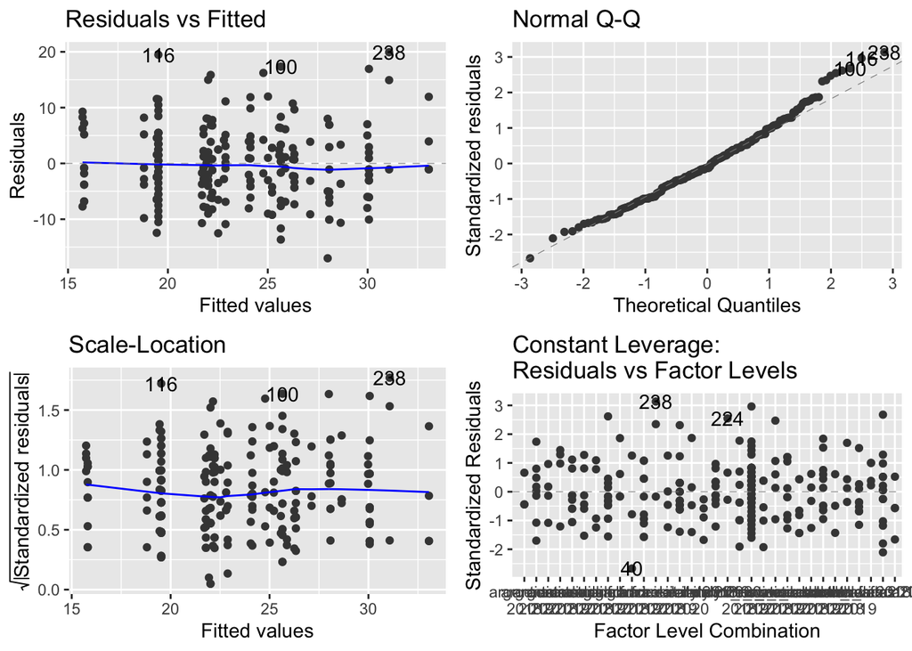

```r
mod2b <- lm(kicks_from_hand ~ team + year, data = model_data)

autoplot(mod2b)
```

```r
summary(mod2b)
```

```
##
## Call:
## lm(formula = kicks_from_hand ~ team + year, data = model_data)
##
## Residuals:
##      Min       1Q   Median       3Q      Max
## -16.9984  -4.1298  -0.8053   3.8672  19.9270
##
## Coefficients:
##                  Estimate Std. Error t value Pr(>|t|)
## (Intercept)      15.72797    1.75242   8.975  < 2e-16 ***
## teamnew_zealand   6.41360    2.12765   3.014 0.002870 **
## teamengland      14.25584    2.10818   6.762 1.16e-10 ***
## teamsouth_africa 10.52425    2.41778   4.353 2.04e-05 ***
## teamireland       6.20748    2.08651   2.975 0.003249 **
## teamitaly         5.97644    2.22264   2.689 0.007706 **
## teamminor_nation  3.71461    1.78979   2.075 0.039082 *
## teamscotland      8.32174    2.19102   3.798 0.000188 ***
## teamwales         9.84384    2.08651   4.718 4.19e-06 ***
## teamfrance       12.27047    2.25876   5.432 1.44e-07 ***
## teamargentina     7.07608    2.29428   3.084 0.002296 **
## year2019          0.08013    1.10995   0.072 0.942511
## year2020          3.07457    1.41913   2.167 0.031323 *
## ---
## Signif. codes:  0 '***' 0.001 '**' 0.01 '*' 0.05 '.' 0.1 ' ' 1
##
## Residual standard error: 6.64 on 225 degrees of freedom
## Multiple R-squared:  0.2738, Adjusted R-squared:  0.2351
## F-statistic:  7.07 on 12 and 225 DF,  p-value: 6.925e-11
```

mod2a has the highest r^2 so is the best option

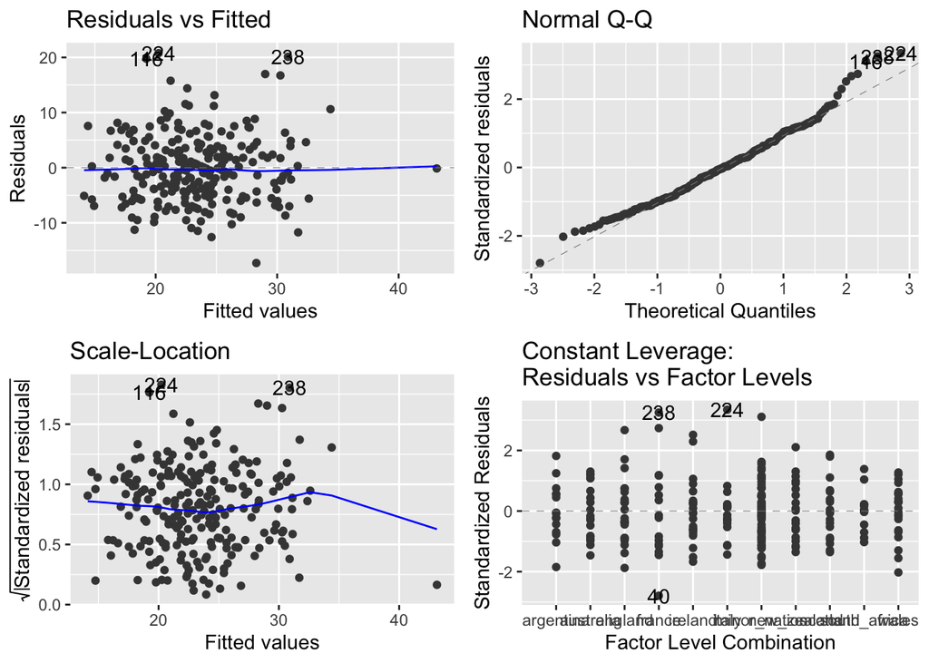

```r
mod3a <- lm(kicks_from_hand ~ team + penalty_goal_successful + lineout_won_own_throw, data = model_data)

autoplot(mod3a)
```

```r
summary(mod3a)
```

```
##
## Call:
## lm(formula = kicks_from_hand ~ team + penalty_goal_successful +
##     lineout_won_own_throw, data = model_data)
##
## Residuals:
##      Min       1Q   Median       3Q      Max
## -17.2853  -4.4684  -0.2637   3.8249  20.7658
##
## Coefficients:
##                         Estimate Std. Error t value Pr(>|t|)
## (Intercept)              11.2164     2.1213   5.287 2.93e-07 ***
## teamnew_zealand           7.3424     2.0680   3.550 0.000468 ***
## teamengland              13.7298     2.0382   6.736 1.34e-10 ***
## teamsouth_africa          9.0278     2.3151   3.900 0.000127 ***
## teamireland               6.4768     2.0171   3.211 0.001516 **
## teamitaly                 6.4469     2.1525   2.995 0.003050 **
## teamminor_nation          4.7086     1.7503   2.690 0.007676 **
## teamscotland              8.6623     2.1187   4.089 6.04e-05 ***
## teamwales                 8.8804     2.0306   4.373 1.87e-05 ***
## teamfrance               12.5700     2.1869   5.748 2.92e-08 ***
## teamargentina             6.2873     2.2225   2.829 0.005092 **
## penalty_goal_successful   1.0529     0.2510   4.195 3.93e-05 ***
## lineout_won_own_throw     0.3213     0.1265   2.540 0.011756 *
## ---
## Signif. codes:  0 '***' 0.001 '**' 0.01 '*' 0.05 '.' 0.1 ' ' 1
##
## Residual standard error: 6.422 on 225 degrees of freedom
## Multiple R-squared:  0.3208, Adjusted R-squared:  0.2846
## F-statistic: 8.855 on 12 and 225 DF,  p-value: 8.071e-14
```

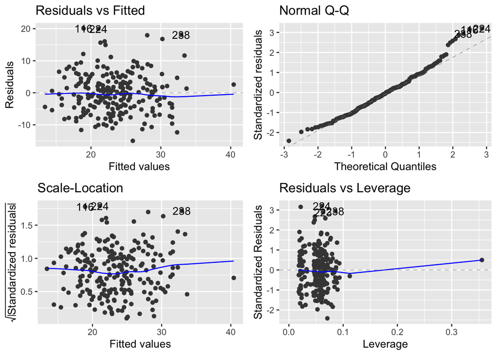

```r
mod3b <- lm(kicks_from_hand~ team + penalty_goal_successful+total_turnovers_gained , data = model_data)

autoplot(mod3b)
```

```r
summary(mod3b)
```

```
##
## Call:
## lm(formula = kicks_from_hand ~ team + penalty_goal_successful +
##     total_turnovers_gained, data = model_data)
##
## Residuals:
##      Min       1Q   Median       3Q      Max
## -14.9882  -4.3515  -0.3063   3.4225  20.0591
##
## Coefficients:
##                         Estimate Std. Error t value Pr(>|t|)
## (Intercept)              12.4051     1.8695   6.635 2.38e-10 ***
## teamnew_zealand           6.4342     2.0778   3.097  0.00221 **
## teamengland              13.3554     2.0398   6.547 3.92e-10 ***
## teamsouth_africa          7.8962     2.3685   3.334  0.00100 **
## teamireland               6.5994     2.0217   3.264  0.00127 **
## teamitaly                 6.9708     2.1737   3.207  0.00154 **
## teamminor_nation          4.1349     1.7277   2.393  0.01752 *
## teamscotland              8.7482     2.1242   4.118 5.36e-05 ***
## teamwales                 8.4065     2.0286   4.144 4.83e-05 ***
## teamfrance               11.9007     2.1853   5.446 1.35e-07 ***
## teamargentina             6.3549     2.2260   2.855  0.00471 **
## penalty_goal_successful   1.0549     0.2515   4.194 3.94e-05 ***
## total_turnovers_gained    0.3365     0.1412   2.383  0.01799 *
## ---
## Signif. codes:  0 '***' 0.001 '**' 0.01 '*' 0.05 '.' 0.1 ' ' 1
##
## Residual standard error: 6.432 on 225 degrees of freedom
## Multiple R-squared:  0.3185, Adjusted R-squared:  0.2822
## F-statistic: 8.763 on 12 and 225 DF,  p-value: 1.136e-13
```

mod3a has the highest r^2 is the better model going forward

```r
mod4a <- lm(kicks_from_hand ~ team + penalty_goal_successful + lineout_won_own_throw  + line_break, data = model_data)

summary(mod4a)
```

```
##
## Call:
## lm(formula = kicks_from_hand ~ team + penalty_goal_successful +
##     lineout_won_own_throw + line_break, data = model_data)
##
## Residuals:
##      Min       1Q   Median       3Q      Max
## -17.5652  -4.5820  -0.3775   3.4798  19.7734
##
## Coefficients:
##                         Estimate Std. Error t value Pr(>|t|)
## (Intercept)              12.3880     2.1591   5.738 3.10e-08 ***
## teamnew_zealand           8.0557     2.0702   3.891 0.000131 ***
## teamengland              14.2589     2.0307   7.022 2.59e-11 ***
## teamsouth_africa          9.3101     2.2954   4.056 6.90e-05 ***
## teamireland               6.2394     1.9998   3.120 0.002046 **
## teamitaly                 6.3275     2.1319   2.968 0.003323 **
## teamminor_nation          4.4513     1.7365   2.563 0.011022 *
## teamscotland              9.0383     2.1039   4.296 2.59e-05 ***
## teamwales                 8.9430     2.0108   4.448 1.37e-05 ***
## teamfrance               12.9566     2.1717   5.966 9.40e-09 ***
## teamargentina             6.1334     2.2016   2.786 0.005796 **
## penalty_goal_successful   1.0205     0.2489   4.100 5.78e-05 ***
## lineout_won_own_throw     0.3373     0.1255   2.689 0.007703 **
## line_break               -0.1878     0.0801  -2.344 0.019939 *
## ---
## Signif. codes:  0 '***' 0.001 '**' 0.01 '*' 0.05 '.' 0.1 ' ' 1
##
## Residual standard error: 6.359 on 224 degrees of freedom
## Multiple R-squared:  0.3371, Adjusted R-squared:  0.2986
## F-statistic:  8.76 on 13 and 224 DF,  p-value: 2.14e-14
```

```r
mod4b <- lm(kicks_from_hand ~ team + penalty_goal_successful + lineout_won_own_throw  + total_turnovers_gained, data = model_data)

summary(mod4b)
```

```
##
## Call:
## lm(formula = kicks_from_hand ~ team + penalty_goal_successful +
##     lineout_won_own_throw + total_turnovers_gained, data = model_data)
##
## Residuals:
##      Min       1Q   Median       3Q      Max
## -16.2352  -4.6630  -0.2109   3.6226  20.9759
##
## Coefficients:
##                         Estimate Std. Error t value Pr(>|t|)
## (Intercept)               8.4312     2.3690   3.559 0.000454 ***
## teamnew_zealand           6.8071     2.0547   3.313 0.001077 **
## teamengland              13.6145     2.0148   6.757 1.20e-10 ***
## teamsouth_africa          7.8249     2.3370   3.348 0.000954 ***
## teamireland               6.6617     1.9947   3.340 0.000983 ***
## teamitaly                 7.1568     2.1457   3.335 0.000997 ***
## teamminor_nation          4.9666     1.7328   2.866 0.004549 **
## teamscotland              8.9835     2.0977   4.283 2.74e-05 ***
## teamwales                 8.8046     2.0070   4.387 1.77e-05 ***
## teamfrance               12.3609     2.1629   5.715 3.48e-08 ***
## teamargentina             6.2590     2.1965   2.850 0.004786 **
## penalty_goal_successful   1.0974     0.2487   4.413 1.59e-05 ***
## lineout_won_own_throw     0.3345     0.1251   2.673 0.008066 **
## total_turnovers_gained    0.3520     0.1394   2.525 0.012269 *
## ---
## Signif. codes:  0 '***' 0.001 '**' 0.01 '*' 0.05 '.' 0.1 ' ' 1
##
## Residual standard error: 6.346 on 224 degrees of freedom
## Multiple R-squared:  0.3396, Adjusted R-squared:  0.3013
## F-statistic:  8.86 on 13 and 224 DF,  p-value: 1.452e-14
```

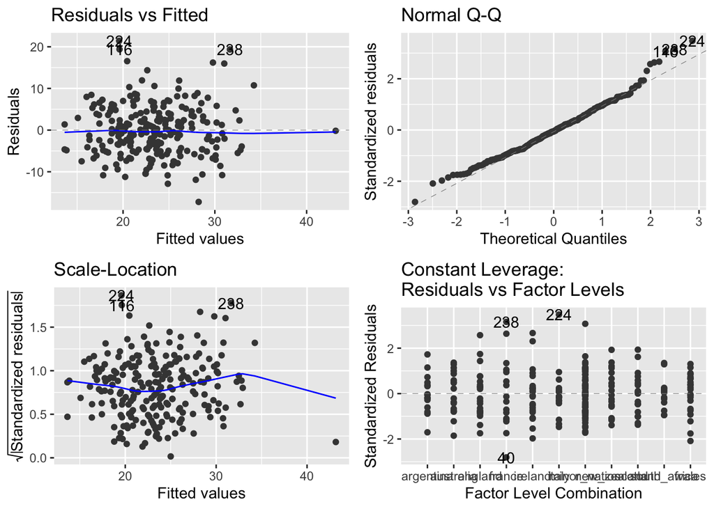

```r
mod4c <- lm(kicks_from_hand ~ team + penalty_goal_successful + lineout_won_own_throw + lineout_won_steal, data = model_data)

autoplot(mod4c)
```

```r
summary(mod4c)
```

```
##
## Call:
## lm(formula = kicks_from_hand ~ team + penalty_goal_successful +
##     lineout_won_own_throw + lineout_won_steal, data = model_data)
##
## Residuals:
##      Min       1Q   Median       3Q      Max
## -17.2346  -4.6338  -0.3509   3.7578  21.4240
##
## Coefficients:
##                         Estimate Std. Error t value Pr(>|t|)
## (Intercept)              10.1566     2.1640   4.693 4.68e-06 ***
## teamnew_zealand           7.2598     2.0526   3.537 0.000492 ***
## teamengland              13.9597     2.0256   6.892 5.53e-11 ***
## teamsouth_africa          8.8287     2.2993   3.840 0.000160 ***
## teamireland               6.8137     2.0080   3.393 0.000816 ***
## teamitaly                 6.8901     2.1463   3.210 0.001521 **
## teamminor_nation          5.3722     1.7650   3.044 0.002616 **
## teamscotland              9.3773     2.1295   4.404 1.65e-05 ***
## teamwales                 9.4615     2.0337   4.652 5.62e-06 ***
## teamfrance               12.8155     2.1734   5.897 1.36e-08 ***
## teamargentina             6.4372     2.2067   2.917 0.003892 **
## penalty_goal_successful   1.0384     0.2492   4.167 4.41e-05 ***
## lineout_won_own_throw     0.3162     0.1256   2.518 0.012509 *
## lineout_won_steal         0.8364     0.3955   2.115 0.035547 *
## ---
## Signif. codes:  0 '***' 0.001 '**' 0.01 '*' 0.05 '.' 0.1 ' ' 1
##
## Residual standard error: 6.373 on 224 degrees of freedom
## Multiple R-squared:  0.3341, Adjusted R-squared:  0.2954
## F-statistic: 8.645 on 13 and 224 DF,  p-value: 3.367e-14
```

team:penalty_goal_successful

```r
mod5a <- lm(kicks_from_hand ~ team + penalty_goal_successful + lineout_won_own_throw + total_turnovers_gained + team:penalty_goal_successful, data = model_data)

summary(mod5a)
```

```
##
## Call:
## lm(formula = kicks_from_hand ~ team + penalty_goal_successful +
##     lineout_won_own_throw + total_turnovers_gained + team:penalty_goal_successful,
##     data = model_data)
##
## Residuals:
##      Min       1Q   Median       3Q      Max
## -12.3340  -4.4637  -0.3151   3.7787  20.9713
##
## Coefficients:
##                                          Estimate Std. Error t value Pr(>|t|)
## (Intercept)                               6.80685    2.96025   2.299 0.022446
## teamnew_zealand                           6.25391    3.30485   1.892 0.059795
## teamengland                              15.67653    3.45825   4.533 9.67e-06
## teamsouth_africa                          7.38015    3.88079   1.902 0.058552
## teamireland                               8.97139    2.85582   3.141 0.001919
## teamitaly                                 8.78397    3.11271   2.822 0.005223
## teamminor_nation                          7.63827    2.57764   2.963 0.003388
## teamscotland                             11.02809    3.06379   3.599 0.000396
## teamwales                                 9.83564    2.91355   3.376 0.000874
## teamfrance                                9.93258    3.31879   2.993 0.003089
## teamargentina                             6.93868    3.60114   1.927 0.055329
## penalty_goal_successful                   1.85454    1.01050   1.835 0.067854
## lineout_won_own_throw                     0.32903    0.12997   2.532 0.012070
## total_turnovers_gained                    0.39764    0.14072   2.826 0.005163
## teamnew_zealand:penalty_goal_successful   0.76559    1.83447   0.417 0.676850
## teamengland:penalty_goal_successful      -1.08850    1.41689  -0.768 0.443196
## teamsouth_africa:penalty_goal_successful -0.04362    1.47764  -0.030 0.976477
## teamireland:penalty_goal_successful      -1.54828    1.31259  -1.180 0.239485
## teamitaly:penalty_goal_successful        -0.93391    1.66588  -0.561 0.575649
## teamminor_nation:penalty_goal_successful -2.16472    1.22839  -1.762 0.079458
## teamscotland:penalty_goal_successful     -1.29352    1.49426  -0.866 0.387645
## teamwales:penalty_goal_successful        -0.64348    1.08844  -0.591 0.555015
## teamfrance:penalty_goal_successful        1.63959    1.51142   1.085 0.279229
## teamargentina:penalty_goal_successful    -0.46733    1.38656  -0.337 0.736413
##
## (Intercept)                              *
## teamnew_zealand                          .
## teamengland                              ***
```

[output cut: 12 more lines]

```
## teamengland:penalty_goal_successful
## teamsouth_africa:penalty_goal_successful
## teamireland:penalty_goal_successful
## teamitaly:penalty_goal_successful
## teamminor_nation:penalty_goal_successful .
## teamscotland:penalty_goal_successful
## teamwales:penalty_goal_successful
## teamfrance:penalty_goal_successful
## teamargentina:penalty_goal_successful
## ---
## Signif. codes:  0 '***' 0.001 '**' 0.01 '*' 0.05 '.' 0.1 ' ' 1
##
## Residual standard error: 6.318 on 214 degrees of freedom
## Multiple R-squared:  0.3746, Adjusted R-squared:  0.3074
## F-statistic: 5.573 on 23 and 214 DF,  p-value: 1.802e-12
```

```r
anova(mod4b, mod5a)
```

```
## Analysis of Variance Table
##
## Model 1: kicks_from_hand ~ team + penalty_goal_successful + lineout_won_own_throw +
##     total_turnovers_gained
## Model 2: kicks_from_hand ~ team + penalty_goal_successful + lineout_won_own_throw +
##     total_turnovers_gained + team:penalty_goal_successful
##   Res.Df    RSS Df Sum of Sq      F Pr(>F)
## 1    224 9021.9
## 2    214 8543.3 10     478.6 1.1988 0.2931
```

mod4b is the best model as team:penalty_goal_successful is not statistically significant

```r
best_model <- mod4b
```

[output not shown]

One possible explanation could be that when a team kicks more than their opposition the game would be played more in the oppositions territory so therefore any penalties that are awarded would be in kicking distance. Although without looking at the type of kicks or why penalties are conceded it is difficult to come to any formal conclusions from this dataset.

## Future Research

This dataset has led to come useful insights, however its does not go the full way in fulling understanding the kicking. With a broader dataset and an analysis of every single kick in the game a better understanding can be made.

[^1]: https://www.macclesfieldrufc.co.uk/2020/12/what-should-our-game-look-like-in-2021/
[^2]: https://www.theguardian.com/sport/2010/feb/01/wales-lee-byrne-six-nations-ban